# Exercise - A Preview of Data Science Tools

```python
height_in = [73, 74, 71, 75, 74, 72, 70, 71, 68, 69, 72, 71]
weight_lb = [170 , 215, 210 , 204, 189, 195, 190, 194, 200, 178, 199, 202]
```

Import the numpy package as np

```python
# Your answer goes here
import numpy as np
```

Create 2 numpy arrays, `np_height_in` & `np_weight_lb`, from height and weight. Hint: one can make a numpy array from a python list, L, by `np.array(L)`.

```python
# Your answer goes here
np_height_in = np.array(height_in)
np_weight_lb = np.array(weight_lb)
```

Checkout the type of np_weight_lb:

```python
# Your answer goes here
type(np_weight_lb)
```

```
numpy.ndarray
```

This is how `np_weight_lb` will look like after the conversion:

```python
np_weight_lb
```

```
array([170, 215, 210, 204, 189, 195, 190, 194, 200, 178, 199, 202])
```

Convert `np_height_in` to meters and call it `np_height_m`, then print it. Hint: Use the formula $height(m) = height(in) * 2.54\ /\ 100$.

```python
# Your answer goes here
np_height_m = np_height_in * 2.54 / 100
print(np_height_m)
```

```
[1.8542 1.8796 1.8034 1.905  1.8796 1.8288 1.778  1.8034 1.7272 1.7526
 1.8288 1.8034]
```

Convert `np_weight_lb` to Kgs and call it `np_weight_kg`, then print it. Hint: Use the formula $weight(kg) = weight(lb) \ /\ 2.2$.

```python
# Your answer goes here
np_weight_kg = np_weight_lb / 2.2
print(np_weight_kg)
```

```
[77.27272727 97.72727273 95.45454545 92.72727273 85.90909091 88.63636364
 86.36363636 88.18181818 90.90909091 80.90909091 90.45454545 91.81818182]
```

Using `np_weight_kg` and `np_height_m` create a simple scatter plot. Hint: to do this you have several options, here are two of them: 1) use `plt.plot(x, y, 'o')`. The option 'o' here creates a scatter plot with circles; checkout help `plt.plot?` to find out about other symbols. 2) use `plt.scatter(x, y)` function.

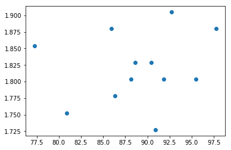

```python
# Your answer goes here
%matplotlib inline
import matplotlib.pyplot as plt
plt.plot(np_weight_kg, np_height_m, 'o')
```

Now try to use the second option. But this time also use `plt.xlabel("X-label")` & `plt.ylabel("Y-label")` to give the axis appropriate names:

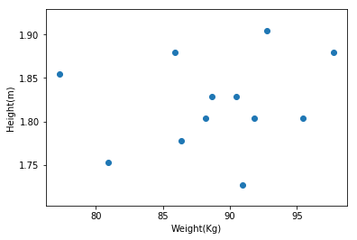

```python
# Your answer goes here
plt.scatter(np_weight_kg, np_height_m)
plt.xlabel("Weight(Kg)")
plt.ylabel("Height(m)")
```

```python
# Your answer goes here
bmi = np.round(np_weight_kg / np_height_m ** 2, 0)
print(bmi)
```

```
[22. 28. 29. 26. 24. 27. 27. 27. 30. 26. 27. 28.]
```

Checkout the type of `bmi`:

```python
# Your answer goes here
type(bmi)
```

```
numpy.ndarray
```

Create a Pandas dafaframe from np_weight_kg, np_height_m, bmi with the column names `weight`, `height`, `bmi`. Call this dataframe `players`:

```python
# Your answer goes here
import pandas as pd
players = pd.DataFrame({'weight': np_weight_kg,
                   'height': np_height_m,
                   'bmi': bmi})
players
```

|  | weight | height | bmi |
| --- | --- | --- | --- |
| 0 | 77.272727 | 1.8542 | 22.0 |
| 1 | 97.727273 | 1.8796 | 28.0 |
| 2 | 95.454545 | 1.8034 | 29.0 |
| 3 | 92.727273 | 1.9050 | 26.0 |
| 4 | 85.909091 | 1.8796 | 24.0 |
| 5 | 88.636364 | 1.8288 | 27.0 |
| 6 | 86.363636 | 1.7780 | 27.0 |
| 7 | 88.181818 | 1.8034 | 27.0 |
| 8 | 90.909091 | 1.7272 | 30.0 |
| 9 | 80.909091 | 1.7526 | 26.0 |
| 10 | 90.454545 | 1.8288 | 27.0 |
| 11 | 91.818182 | 1.8034 | 28.0 |

See if you can reproduce the above plot by using DataFrame method `.plot.scatter()` on `players` DataFrame:

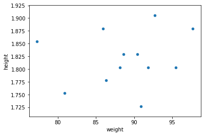

```python
# Your answer goes here
players.plot.scatter(x='weight', y='height')
```

Now with ggplot style:

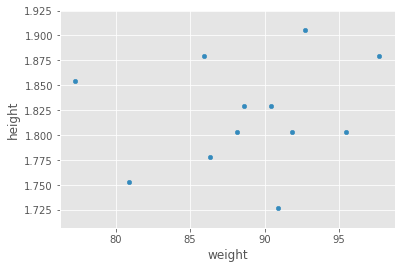

```python
# Your answer goes here
plt.style.use('ggplot')
players.plot.scatter(x='weight', y='height')
```

Notice that pandas way has the advantage that x and y axis automatically get populated by the column names.